# Smart devices usage

# CONTEXT

Bellabit is a high-tech company that manufactures health-focused smart products since 2013. Their products:

- **Bellabeat app**: provides users with health data related to their activity, sleep, stress, menstrual cycle, and mindfulness habits. It connects to their line of smart wellness products.
- **Leaf**: a wellness tracker can be worn as a bracelet, necklace, or clip. It connects to the Bellabeat app to track activity, sleep, and stress.
- **Time**: a wellness watch to track user activity, sleep, and stress. It connects to the Bellabeat app to provide daily wellness.
- **Spring**: a water bottle that tracks daily water intake that connects to the Bellabeat app to track hydration levels.
- **Bellabeat membership**: a subscription-based membership program for users that gives 24/7 access to fully personalized guidance on nutrition, activity, sleep, health and beauty, and mindfulness based on their lifestyle and goals.

Bellabeat wants to get insights about the smart devices usage in order to obtain trends that help their marketing strategy.

# ASK

## Business task

Analyze smart device usage to gain insights into how people are already using their smart devices and provide high-level recommendations to improve marketing strategies for Bellabeat.

## Business use case

- Determine trends for smart device usage
- How could these trends apply to Bellabeat ‘Time’ customers?
- How could these trends help to improve Bellabeat’s marketing strategy?

# PREPARE

For the analysis, I will use a custom survey (First-party data) in order to get updated data related to smartwatch usages, and use R with RStudio to perform the analysis task.

## Building the survey

### Platform

#### Smartwatch usage questions

- Main usage: multiple choice, with the option to add a custom answer
- Usage periodicity: scale from 0 to 7 representing usage in days
- Brand: multiple choice, listing main brand collected from sites like Amazon, Tiendamia, Mercado Libre. Option for add custom answer.
- Features used: checkboxs, listing main features offered by smartwatches on the market. Option for add custom answer.
- Tracked functionalities: checkboxs, listing main tracker options offers the smartwatches on the market. Option for add custom answer.
- Activities tracked: checkboxs, listing main sport activities tracked for the smartwatches on the market. Option for add custom answer.

## Importing data

We need to import both survey files, the English and the Spanish version

```r
swu_file_en <- read_csv("Smartwatch usage - english.csv")
swu_file_es <- read_csv("Smartwatch usage - Spanish.csv")
```

### Get preview of imported data

We need to check if there is any error importing the files

```r
head(swu_file_en)
```

| Timestamp | What gender do you identify with? | How old are you? | Where do you live? | Which is the main use you give to your smartwatch? | How many days do you use any functionality of your smartwatch? | Which is the brand of your smartwatch? | What are the features you use on your smartwatch? | What features do you use to track with your smartwatch? | What sport activities do you track with your smartwatch? |
| --- | --- | --- | --- | --- | --- | --- | --- | --- | --- |
| 1/26/2024 14:42:08 | Female | 26 - 35 | Central and South America | Training tracker | 3 | Generic | Multisport tracker, Time display, Sedentary reminder | Multisport tracker, Blood pressure monitor, Calories tracker, Distance tracker, Heart rate monitor, Water monitor | Walking |
| 1/26/2024 14:42:34 | Male | 36 - 45 | Central and South America | Shortcut to cell functionalities | 6 | Samsung | Alarm clock, Notifications, Phone calls, Time display, Music, Voice control | Distance tracker, Heart rate monitor, Sleep monitor | Walking, Running, Cycling |
| 1/26/2024 14:44:15 | Male | 26 - 35 | Central and South America | Health tracker | 4 | Samsung | Alarm clock, GPS, Notifications, Sedentary reminder | Blood pressure monitor, Calories tracker, Distance tracker, Heart rate monitor, Sleep monitor | Walking |
| 1/26/2024 14:47:57 | Female | 36 - 45 | Europe | Training tracker | 7 | Apple | Multisport tracker, Alarm clock, Notifications, Time display, Music, Sedentary reminder | Multisport tracker, Blood pressure monitor, Calories tracker, Distance tracker, Heart rate monitor, Sleep monitor, Stress control | Walking, Cycling, Swimming |
| 1/26/2024 14:52:46 | Female | 36 - 45 | Central and South America | Training tracker | 4 | Garmin | GPS, Time display | Distance tracker | Running |
| 1/26/2024 14:55:54 | Male | 26 - 35 | Central and South America | Training tracker | 1 | Garmin | Multisport tracker, Alarm clock, GPS, Notifications, Time display, Music, Weather | Multisport tracker, Calories tracker, Distance tracker, Heart rate monitor, Sleep monitor, Weight monitor, Mindfulness | Walking, Cycling, Swimming, Skiing |

```r
head(swu_file_es)
```

| Timestamp | ¿Con qué genero te identificas? | ¿Qué edad tenés? | ¿Dónde vivís? | ¿Cuál es el principal uso que le das a tu reloj inteligente? | ¿Cuántos días utilizas alguna funcionalidad de tu reloj inteligente? | ¿Cuál es la marca de tu reloj inteligente? | ¿Cuáles son las funciones que utilizas en tu reloj inteligente? | ¿Qué funciones utilizas para realizar un seguimiento con tu reloj inteligente? | ¿Qué actividades deportivas seguís con tu reloj inteligente? |
| --- | --- | --- | --- | --- | --- | --- | --- | --- | --- |
| 1/26/2024 15:20:29 | Masculino | 36 - 45 | América Central y Sudamérica | Seguimiento de entrenamiento | 7 | Garmin | Seguimiento de múltiples deportes, Alarma, GPS, Notificaciones, Visualización de la hora | Seguimiento de múltiples deportes, Monitor de presión arterial, Calorias, Distancia, Monitor de ritmo cardíaco, Monitor de sueño, Control de estrés | Caminata, Natación |
| 1/26/2024 15:23:37 | Femenino | 36 - 45 | América Central y Sudamérica | Acceso directo a las funcionalidades del celular | 7 | Samsung | Alarma, Cámara, GPS, Notificaciones, Llamadas telefónicas, Mensajes de texto, Visualización de la hora, Email, Música | Monitor de presión arterial, Calorias, Distancia, Monitor de ritmo cardíaco, Monitor de agua bebida | Caminata |
| 1/26/2024 15:24:45 | Femenino | 36 - 45 | América Central y Sudamérica | Seguimiento de salud | 6 | Samsung | Seguimiento de múltiples deportes, Alarma, Visualización de la hora | Seguimiento de múltiples deportes, Distancia, Monitor de sueño, Control de estrés | Caminata, Natación |
| 1/26/2024 15:26:59 | Femenino | 36 - 45 | América Central y Sudamérica | Seguimiento de entrenamiento | 7 | Xiaomi | Seguimiento de múltiples deportes, Visualización de la hora, Recordatorio de sedentarismo | Seguimiento de múltiples deportes, Distancia | Caminata, Gimnasio |
| 1/26/2024 15:27:23 | Masculino | Más de 66 | América Central y Sudamérica | Seguimiento de entrenamiento | 5 | Generic | Llamadas telefónicas | Seguimiento de múltiples deportes | Caminata |
| 1/26/2024 15:31:44 | Masculino | 36 - 45 | América Central y Sudamérica | Seguimiento de salud | 3 | Xiaomi | Notificaciones, Visualización de la hora | Monitor de ritmo cardíaco, Monitor de sueño | Caminata |

### Changing column names for both files

Every file has different column names because they were shared in different languages, though they show the same information

```r
swu_es <- rename(swu_file_es,
       'gender_dirty' = '¿Con qué genero te identificas?',
       'age_dirty' = '¿Qué edad tenés?',
       'location_dirty' = '¿Dónde vivís?',
       'usage_dirty' = '¿Cuál es el principal uso que le das a tu reloj inteligente?',
       'periodicity' = '¿Cuántos días utilizas alguna funcionalidad de tu reloj inteligente?',
       'brand_dirty' = '¿Cuál es la marca de tu reloj inteligente?',
       'features_dirty' = '¿Cuáles son las funciones que utilizas en tu reloj inteligente?',
       'functionalities_dirty' = '¿Qué funciones utilizas para realizar un seguimiento con tu reloj inteligente?',
       'activities_dirty' = '¿Qué actividades deportivas seguís con tu reloj inteligente?'
       )

swu_en <- rename(swu_file_en,
       'gender_dirty' = 'What gender do you identify with?',
       'age_dirty' = 'How old are you?',
       'location_dirty' = 'Where do you live?',
       'usage_dirty' = 'Which is the main use you give to your smartwatch?',
       'periodicity' = 'How many days do you use any functionality of your smartwatch?',
       'brand_dirty' = 'Which is the brand of your smartwatch?',
       'features_dirty' = 'What are the features you use on your smartwatch?',
       'functionalities_dirty' = 'What features do you use to track with your smartwatch?',
       'activities_dirty' = 'What sport activities do you track with your smartwatch?'
       )
```

### Binding files

We need to get one file to process the information

```r
swu_dirty <- union(swu_es, swu_en)
```

### Checking resulting dataframe

The resulting dataframe should have the sum of rows of both files

```r
skim_without_charts(swu_dirty)
```

```
── Data Summary ────────────────────────
                           Values
Name                       swu_dirty
Number of rows             147
Number of columns          10
_______________________
Column type frequency:
  character                9
  numeric                  1
________________________
Group variables            None
```

|  | skim_variable | n_missing | complete_rate | min | max | empty | n_unique | whitespace |
| --- | --- | --- | --- | --- | --- | --- | --- | --- |
| 1 | Timestamp | 0 | 1.0000000 | 16 | 18 | 0 | 147 | 0 |
| 2 | gender_dirty | 0 | 1.0000000 | 4 | 17 | 0 | 6 | 0 |
| 3 | age_dirty | 0 | 1.0000000 | 7 | 9 | 0 | 6 | 0 |
| 4 | location_dirty | 0 | 1.0000000 | 4 | 28 | 0 | 7 | 0 |
| 5 | usage_dirty | 0 | 1.0000000 | 5 | 76 | 0 | 18 | 0 |
| 6 | brand_dirty | 0 | 1.0000000 | 3 | 41 | 0 | 17 | 0 |
| 7 | features_dirty | 0 | 1.0000000 | 6 | 207 | 0 | 120 | 0 |
| 8 | functionalities_dirty | 0 | 1.0000000 | 8 | 185 | 0 | 103 | 0 |
| 9 | activities_dirty | 4 | 0.9727891 | 5 | 77 | 0 | 64 | 0 |

|  | skim_variable | n_missing | complete_rate | mean | sd | p0 | p25 | p50 | p75 | p100 |
| --- | --- | --- | --- | --- | --- | --- | --- | --- | --- | --- |
| 1 | periodicity | 0 | 1 | 5.14966 | 2.071839 | 0 | 4 | 6 | 7 | 7 |

# PROCESS

## Preparing environment for cleaning data

### General cleaning

We perform a general cleaning on the data: * clear names (to snake_case) * remove empty values

```r
swu <- swu_dirty %>% clean_names() %>% remove_empty(c("rows", "cols"))
```

### Translating fields

As we share the survey in 2 languages (English and Spanish), many of the answers need to be unified to count as one type of answer

## Cleaning columns

### Gender

```r
unique(swu['gender_dirty'])
```

| gender_dirty |
| --- |
| Masculino |
| Femenino |
| Prefiero no decir |
| Female |
| Male |
| Prefer not to say |

```r
swu <- mutate(swu, gender = case_when(
  gender_dirty == 'Masculino' ~ 'Male',
  gender_dirty == 'Femenino' ~ 'Female',
  gender_dirty == 'Prefiero no decir' ~ 'Prefer not to say',
  TRUE ~ gender_dirty
))
unique(swu['gender'])
```

| gender |
| --- |
| Male |
| Female |
| Prefer not to say |

### Age

```r
unique(swu['age_dirty'])
```

| age_dirty |
| --- |
| 36 - 45 |
| Más de 66 |
| 26 - 35 |
| 56 - 65 |
| 15 - 25 |
| 46 - 55 |

```r
swu <- mutate(swu, age = case_when(
  age_dirty == 'Más de 66' ~ 'More than 66',
  TRUE ~ age_dirty
))
unique(swu['age'])
```

| age |
| --- |
| 36 - 45 |
| More than 66 |
| 26 - 35 |
| 56 - 65 |
| 15 - 25 |
| 46 - 55 |

### User location

```r
unique(swu['location_dirty'])
```

| location_dirty |
| --- |
| América Central y Sudamérica |
| Europa |
| África |
| Central and South America |
| Europe |
| North America |
| Asia |

```r
swu <- mutate(swu, location = case_when(
  location_dirty == 'Norteamérica' ~ 'North America',
  location_dirty == 'América Central y Sudamérica' ~ 'South America',
  location_dirty == 'Central and South America' ~ 'South America',
  location_dirty == 'Europa' ~ 'Europe',
  location_dirty == 'África' ~ 'Africa',
  location_dirty == 'Oceanía' ~ 'Australia',
  TRUE ~ location_dirty
))
unique(swu['location'])
```

| location |
| --- |
| South America |
| Europe |
| Africa |
| North America |
| Asia |

### Main usage

```r
unique(swu['usage_dirty'])
```

| usage_dirty |
| --- |
| Seguimiento de entrenamiento |
| Acceso directo a las funcionalidades del celular |
| Seguimiento de salud |
| Todas las opciones |
| Ver la hora |
| Las dos primeras opciones |
| Seguimiento de salud, datos atmosfericos, livetracking |
| No tengo reloj inteligente |
| Más que nada por la hora , para no tener que estar viendo el celular siempre |
| Reloj |

[output cut: 8 more lines]

```r
swu <- mutate(swu, usage = case_when(

  grepl('(?i)entrenamiento|(?i)training', usage_dirty) ~ 'Training tracker',
  grepl('(?i)celular|(?i)cell|(?i)notification', usage_dirty) ~ 'Shortcut to cell',
  grepl('(?i)salud|(?i)health', usage_dirty) ~ 'Health tracker',

  # 'Other' options listed below
  grepl('(?i)opciones|(?i)options', usage_dirty) ~ 'All options',
  grepl('(?i)hora|(?i)reloj|(?i)time|(?i)watch', usage_dirty) ~ 'Watch usage',
  grepl('(?i)pago|(?i)pay|(?i)payment', usage_dirty) ~ 'Payments',

  TRUE ~ usage_dirty
))
unique(swu['usage'])
```

| usage |
| --- |
| Training tracker |
| Shortcut to cell |
| Health tracker |
| All options |
| Watch usage |
| Payments |

### Brand

```r
unique(swu['brand_dirty'])
```

| brand_dirty |
| --- |
| Garmin |
| Samsung |
| Xiaomi |
| Generic |
| Fitbit |
| Huawei |
| Google |
| Apple |
| Amazfit |
| Suunto |

[output cut: 7 more lines]

```r
swu <- mutate(swu, brand = case_when(

  grepl('I have Samsung and Colmi. Now I use Colmi', brand_dirty) ~ 'Colmi',
  grepl('(?i)Suunto', brand_dirty) ~ 'Suunto',
  grepl('Sinrelojinteligent|(?i)xxx', brand_dirty) ~ NA,

  TRUE ~ brand_dirty
))
unique(swu['brand'])
```

| brand |
| --- |
| Garmin |
| Samsung |
| Xiaomi |
| Generic |
| Fitbit |
| Huawei |
| Google |
| Apple |
| Amazfit |
| Suunto |

[output cut: 5 more lines]

## Group by demographic fields

We need to create new data frames for every multiple-value columns along with demographic fields for individual analysis

### Features

‘Features’ is a question for knowing which are the common uses that an user gives to their smartwatch as a device.  
The users should mark as many features as they used on their smartwatches. So, we need to split all this checked options into different rows to process them that way.

```r
  features_dirty <- select(swu, timestamp, gender, age, location, periodicity, brand, features_dirty)
```

```r
  features_rows <- separate_longer_delim(features_dirty, features_dirty, ', ')
```

```r
unique(features_rows['features_dirty'])
```

| features_dirty |
| --- |
| Seguimiento de múltiples deportes |
| Alarma |
| GPS |
| Notificaciones |
| Visualización de la hora |
| Cámara |
| Llamadas telefónicas |
| Mensajes de texto |
| Email |
| Música |

[output cut: 32 more lines]

We will create two different columns for features, the first is to translate the values and the second one to group them into a bigger category

```r
features_rows <- mutate(features_rows, features = case_when(
  grepl('(?i)deporte|(?i)sport|(?i)pasos', features_dirty) ~ 'Sports monitor',
  grepl('(?i)alarma|(?i)alarm', features_dirty) ~ 'Alarm',
  grepl('(?i)sedentary|(?i)sedentarismo', features_dirty) ~ 'Sedentary reminder',
  grepl('(?i)agua|(?i)water', features_dirty) ~ 'Water drink reminder',
  grepl('(?i)notificaciones|(?i)notifications', features_dirty) ~ 'Cell notifications',
  grepl('(?i)slack|(?i)text', features_dirty) ~ 'Text messages',
  grepl('(?i)calendar', features_dirty) ~ 'Calendar',
  grepl('(?i)música', features_dirty) ~ 'Music',
  grepl('(?i)cámara|(?i)camara', features_dirty) ~ 'Camara',
  grepl('(?i)teléfono|(?i)telefónicas', features_dirty) ~ 'Phone calls',
  grepl('(?i)voz', features_dirty) ~ 'Voice control',
  grepl('(?i)hora|(?i)time|(?i)watch', features_dirty) ~ 'Watch',
  grepl('(?i)pago', features_dirty) ~ 'Contactless payments',
  grepl('(?i)calorías|(?i)salud|(?i)estres|(?i)sueño|(?i)presion|(?i)cardiaca', features_dirty) ~ 'Health monitor',
  grepl('(?i)clima|(?i)atmosfericos|(?i)weather', features_dirty) ~ 'Weather monitor',

  TRUE ~ features_dirty
))
unique(features_rows['features'])
```

| features |
| --- |
| Sports monitor |
| Alarm |
| GPS |
| Cell notifications |
| Watch |
| Camara |
| Phone calls |
| Text messages |
| Email |
| Music |

[output cut: 8 more lines]

```r
features_grouped_rows <- mutate(features_rows, features_grouped = case_when(
  grepl('(?i)sports|(?i)sport', features) ~ 'Sports monitor',
  grepl('(?i)alarm|(?i)sedentary|(?i)water', features) ~ 'Activity reminder',
  grepl('(?i)notifications|(?i)text|(?i)email|(?i)calendar', features) ~ 'Cell notifications',
  grepl('(?i)music|(?i)camara|(?i)phone|(?i)voice', features) ~ 'Cell control',
  grepl('(?i)time|(?i)watch', features) ~ 'Watch',
  grepl('(?i)payment|(?i)SOS|(?i)GPS', features) ~ 'Other features',
  grepl('(?i)calories|(?i)stress|(?i)sleep|(?i)presion|(?i)cardiac', features) ~ 'Health monitor',
  grepl('(?i)weather', features) ~ 'Weather monitor',

  TRUE ~ features
))
unique(features_grouped_rows['features_grouped'])
```

| features_grouped |
| --- |
| Sports monitor |
| Activity reminder |
| Other features |
| Cell notifications |
| Watch |
| Cell control |
| Health monitor |
| Weather monitor |

### Tracked functionalities

‘tracked_functionalities’ is a question to determine which are the features tracked by the users through their smartwatches. The users should mark as many features as they track on their smartwatches. So, we need to split all this checked options into different rows to process them that way.

```r
  functionalities_dirty <- select(swu, timestamp, gender, age, location, periodicity, brand, functionalities_dirty)
```

```r
  functionalities_rows <- separate_longer_delim(functionalities_dirty, functionalities_dirty, ', ')
```

```r
unique(functionalities_rows['functionalities_dirty'])
```

| functionalities_dirty |
| --- |
| Seguimiento de múltiples deportes |
| Monitor de presión arterial |
| Calorias |
| Distancia |
| Monitor de ritmo cardíaco |
| Monitor de sueño |
| Control de estrés |
| Monitor de agua bebida |
| Monitor de peso |
| Monitor de temperatura |

[output cut: 17 more lines]

```r
functionalities_grouped_rows <- mutate(functionalities_rows, functionalities = case_when(
  grepl('(?i)deporte|(?i)sport|(?i)pasos', functionalities_dirty) ~ 'Sports',
  grepl('(?i)presión arterial|(?i)blood', functionalities_dirty) ~ 'Blood pressure',
  grepl('(?i)calorías|(?i)calorias|(?i)calories', functionalities_dirty) ~ 'Calories',
  grepl('(?i)distancia|(?i)distance', functionalities_dirty) ~ 'Distance',
  grepl('(?i)cardíaco|(?i)heart', functionalities_dirty) ~ 'Heart rate',
  grepl('(?i)sueño|(?i)sleep', functionalities_dirty) ~ 'Sleep',
  grepl('(?i)agua|(?i)water', functionalities_dirty) ~ 'Water',
  grepl('(?i)peso|(?i)weight', functionalities_dirty) ~ 'Weight',
  grepl('(?i)temperatura|(?i)temperature', functionalities_dirty) ~ 'Temperature',
  grepl('(?i)menstrual', functionalities_dirty) ~ 'Menstrual health',
  grepl('(?i)altitud|(?i)altitude|elevation', functionalities_dirty) ~ 'Altitude',
  grepl('(?i)oxigeno|(?i)oxígeno', functionalities_dirty) ~ 'Oxygen',
  grepl('(?i)estrés|(?i)stress', functionalities_dirty) ~ 'Stress',
  grepl('(?i)noise|(?i)ruido', functionalities_dirty) ~ 'Noise',
  grepl('(?i)hora', functionalities_dirty) ~ NA,

  TRUE ~ functionalities_dirty
))
unique(functionalities_grouped_rows['functionalities'])
```

| functionalities |
| --- |
| Sports |
| Blood pressure |
| Calories |
| Distance |
| Heart rate |
| Sleep |
| Stress |
| Water |
| Weight |
| Temperature |

[output cut: 6 more lines]

### Activities

‘activities’ is a question to determine which are the sport activities most tracked for the smartwatch users.They should mark as many activities as they track on their smartwatches. So, we need to split all this checked options into different rows to process them that way.

```r
  activities_dirty <- select(swu, timestamp, gender, age, location, periodicity, brand, activities_dirty)
```

```r
  activities_rows <- separate_longer_delim(activities_dirty, activities_dirty, ', ')
```

```r
unique(activities_rows['activities_dirty'])
```

| activities_dirty |
| --- |
| Caminata |
| Natación |
| Gimnasio |
| Ninguna |
| Correr |
| Tenis |
| Ciclismo |
| Pilates |
| Entrenamiento libre |
| Escalada |

[output cut: 42 more lines]

```r
activities_grouped_rows <- mutate(activities_rows, activities = case_when(
  grepl('(?i)caminata|(?i)pasos', activities_dirty) ~ 'Walking',
  grepl('(?i)hiking|(?i)trakking|(?i)senderismo', activities_dirty) ~ 'Hiking / Trekking',
  grepl('(?i)natación|(?i)natacion', activities_dirty) ~ 'Swimming',
  grepl('(?i)gimnasio|(?i)gym|(?i)entrenamiento', activities_dirty) ~ 'General gym training',
  grepl('(?i)fuerza|(?i)crossfit|(?i)funcional|(?i)cross|(?i)strong|(?i)fitness|(?i)weight|(?i)strength|(?i)workouts', activities_dirty) ~ 'Strength and endurance sports',
  grepl('(?i)pilates|(?i)yoga|(?i)stretching|(?i)meditation', activities_dirty) ~ 'Relaxing sports',
  grepl('(?i)ninguna|(?i)hora', activities_dirty) ~ NA,
  grepl('(?i)tenis', activities_dirty) ~ 'Tennis',
  grepl('(?i)correr', activities_dirty) ~ 'Running',
  grepl('(?i)ciclismo', activities_dirty) ~ 'Cycling',
  grepl('(?i)futbol', activities_dirty) ~ 'Football / Soccer',
  grepl('(?i)enduro', activities_dirty) ~ 'Enduro motorcycle',
  grepl('(?i)splitboard', activities_dirty) ~ 'Splitboarding',
  grepl('(?i)buceo', activities_dirty) ~ 'Diving',
  grepl('(?i)patinar', activities_dirty) ~ 'Skating',
  grepl('(?i)escalada', activities_dirty) ~ 'Climbing',
  grepl('(?i)esqui|(?i)esquí|(?i)ski', activities_dirty) ~ 'Skiing',
  grepl('(?i)bailar|(?i)dancing', activities_dirty) ~ 'Dancing',

  TRUE ~ activities_dirty
))
unique(activities_grouped_rows['activities'])
```

| activities |
| --- |
| Walking |
| Swimming |
| General gym training |
| NA |
| Running |
| Tennis |
| Cycling |
| Relaxing sports |
| Climbing |
| Strength and endurance sports |

[output cut: 8 more lines]

# ANALIZE

We need to identify trends and relationships within data so we can accurately answer the question made

```r
install.packages('ggplot2')
```

```
Error in install.packages : Updating loaded packages
```

```r
install.packages('lessR')
install.packages("ggplot2")
install.packages('scales')
```

```
Error in install.packages : Updating loaded packages
```

```r
library(ggplot2)
library(lessR)
library(scales)
```

## Demographic

We want to identify demographic trends on the sample * Gender * Age * Geographic location

### Gender

We identified two main genders and a third for those who rater not say.

```
>>> Note: gender_table is not in a data frame (table)
>>> Note: gender_table is not in a data frame (table)
>>> suggestions
PieChart(gender_table, hole=0)  # traditional pie chart
PieChart(gender_table, values="%")  # display %'s on the chart
PieChart(gender_table)  # bar chart
Plot(gender_table)  # bubble plot
Plot(gender_table, values="count")  # lollipop plot

--- gender_table ---

               Female   Male  Prefer not to say     Total
Frequencies:       60     85                  2       147
Proportions:    0.408  0.578              0.014     1.000

Chi-squared test of null hypothesis of equal probabilities
  Chisq = 74.000, df = 2, p-value = 0.000
```

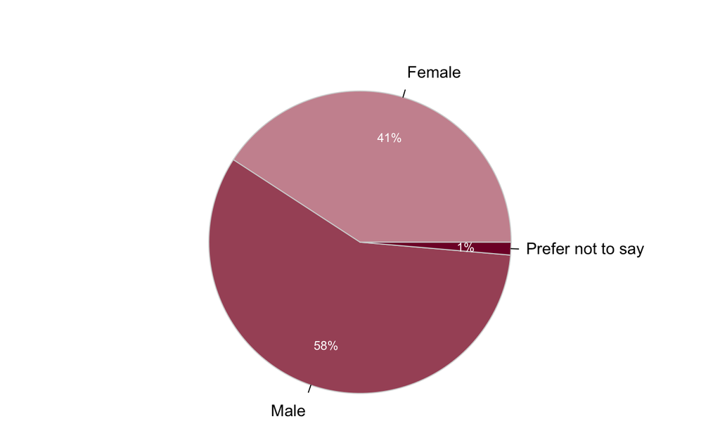

```r
gender_table <- table(swu['gender'])

PieChart(gender_table, hole = 0, values = "%", main = "", fill = "reds")
```

### Age

We create age groups, with a range of 10 years each.

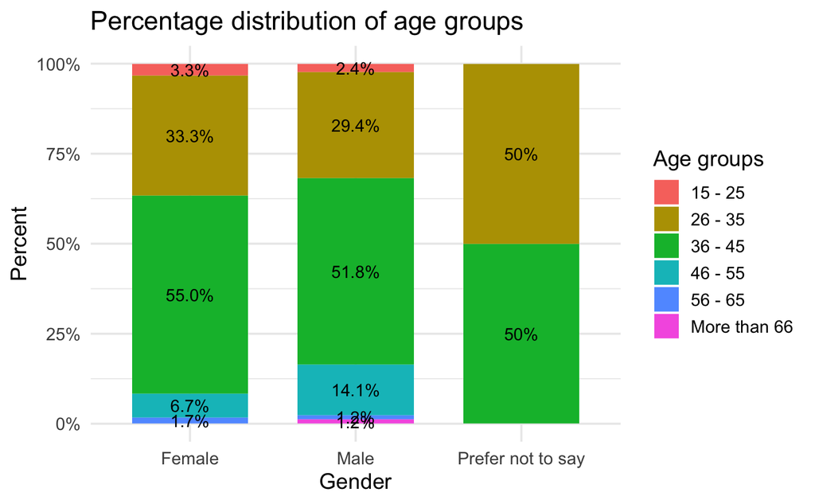

```r
age_perc <- swu %>%
  group_by(gender, age) %>%
  summarise(count = n()) %>%
  mutate(perc = count/sum(count), ratio = scales::percent(count/sum(count)))
# Chart
ggplot(age_perc, aes(x = factor(gender), y = perc, fill = factor(age))) +
  geom_bar(stat="identity", width = 0.7, position="fill") +
  labs(x = "Gender", y = "Percent", fill = "age", title = 'Percentage distribution of age groups') +
  theme_minimal(base_size = 14) +
  geom_text(data = age_perc, aes(y = perc, label = ratio), position = position_stack(vjust = 0.5)) +
  scale_y_continuous(labels = scales::percent_format(accuracy = 5L)) +
  guides(fill = guide_legend(title = "Age groups"))
```

### Geographic location

We want to know which is the continent distribution of smartwatches users

```r
install.packages("rnaturalearth")
install.packages("scales")
install.packages("sf")
```

```
Error in download.file(url, destfile, method, mode = "wb", ...) :
  download from 'https://cran.rstudio.com/bin/macosx/big-sur-x86_64/contrib/4.3/sf_1.0-15.tgz' failed
```

```r
# library(dplyr) # For data wrangling/pipes e.g. %>%
library(sf) # For spatial data
library(rnaturalearth) # For map data
#library(ggplot2) # For plotting

# Tell sf to treat world map data as a 'flat' surface instead of a sphere
sf_use_s2(FALSE)
```

```
Spherical geometry (s2) switched off
```

```r
# Import world map, dissolve/union polygons by continent, and add bubble lon/lat
# locations for plotting
continents <- ne_countries(returnclass='sf') %>%
  # Russia has incorrect continent value, so need to change it
  mutate(continent = ifelse(sovereignt == "Russia", "Asia", continent)) %>%
  group_by(continent) %>%
  summarise(geom = st_union(geometry)) %>%
  filter(!continent == "Seven seas (open ocean)") %>%
  mutate(centroid_lon = st_coordinates(st_centroid(.))[,1],
         centroid_lat = st_coordinates(st_centroid(.))[,2])
```

[output not shown]

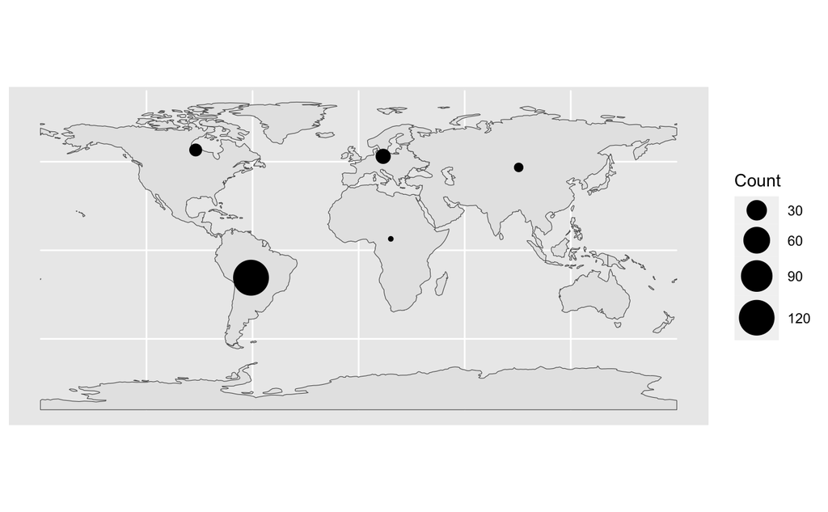

```r
# Your count data
dat <- read.table(text = "Africa;1
Asia;3
Europe;13
North America;8
South America;122", header = FALSE, sep = ";")
colnames(dat) <- c("continent", "count")

# Join count data to continents
continents <- left_join(continents, dat, by = "continent")

# Plot
ggplot(data = continents) +
  geom_sf() +
  geom_point(aes(x = centroid_lon, y = centroid_lat, size = count)) +
  scale_size(range = c(1, 10)) +
  labs(size = "Count") +
  theme(axis.title = element_blank())
```

```r
# It is a good habit to turn S2 back on after you are done
#sf_use_s2(TRUE)
```

## Smartwatch usage trends

We want to identify trends on the sample * Periodicity * Brand * Usage * Features * Functionalities * Activities

```r
library(forcats)
```

### Periodicity

We want to identify how many days the users used their smartwatches.

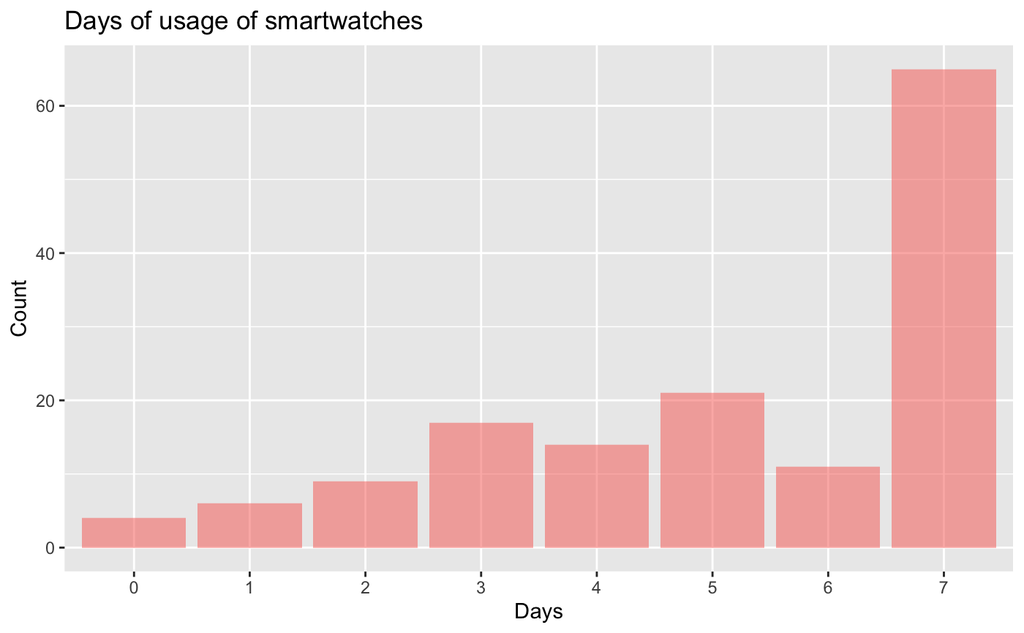

```r
swu %>%
  ggplot(aes(x = factor(periodicity), fill = "orange", alpha=.6, width=.4)) +
  geom_bar() +
  theme(legend.position="none")+
  labs(x = "Days", y = "Count", title = 'Days of usage of smartwatches')
```

### Brand

We want to know which are the main brands on the market

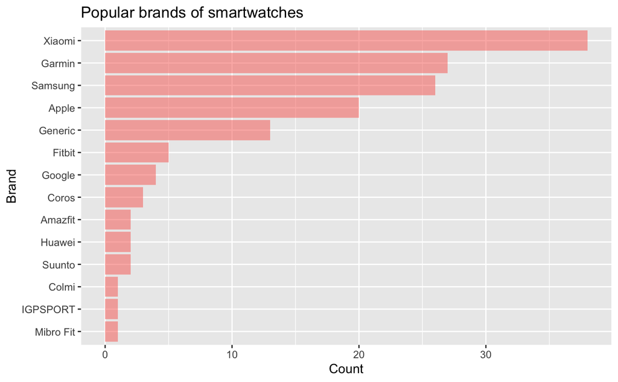

```r
# Reorder from highest frequency to lowest frequency
swu %>% drop_na(brand) %>%
  ggplot(aes(x = fct_rev(fct_infreq(brand)), fill = "orange", alpha=.6, width=.4)) +
  geom_bar() +
  coord_flip() +
  theme(legend.position="none")+
  labs(x = "Brand", y = "Count", title = 'Popular brands of smartwatches')
```

### Main usage

We want to identify which is the main usage the users give to their smartwatches.

[figure not shown]

```r
# Reorder from highest frequency to lowest frequency
swu %>%
  ggplot(aes(x = fct_rev(fct_infreq(usage)), fill = "orange", alpha=.6, width=.4)) +
  geom_bar() +
  coord_flip() +
  theme(legend.position="none")+
  labs(x = "Main usage", y = "Count", title = 'Main usage of smartwatches')
```

### Features

We want to identify which are the detailed smartwatch features the users use the most.

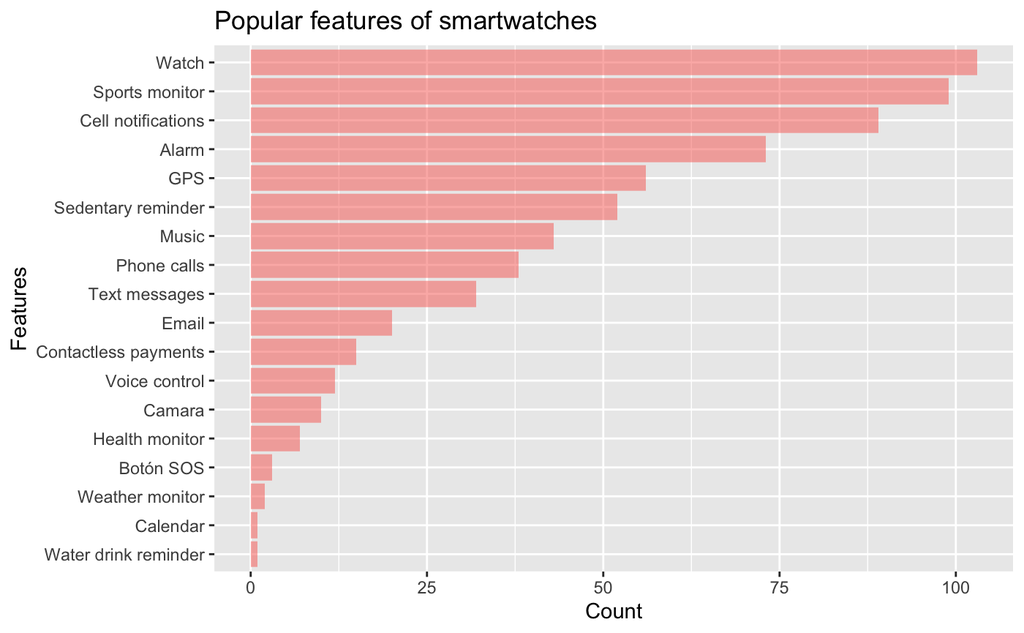

```r
# Reorder from highest frequency to lowest frequency
features_rows %>%
  ggplot(aes(x = fct_rev(fct_infreq(features)), fill = "orange", alpha=.6, width=.4)) +
  geom_bar() +
  coord_flip() +
  theme(legend.position="none")+
  labs(x = "Features", y = "Count", title = 'Popular features of smartwatches')
```

We create larger categories from features to get a bigger picture of the trends

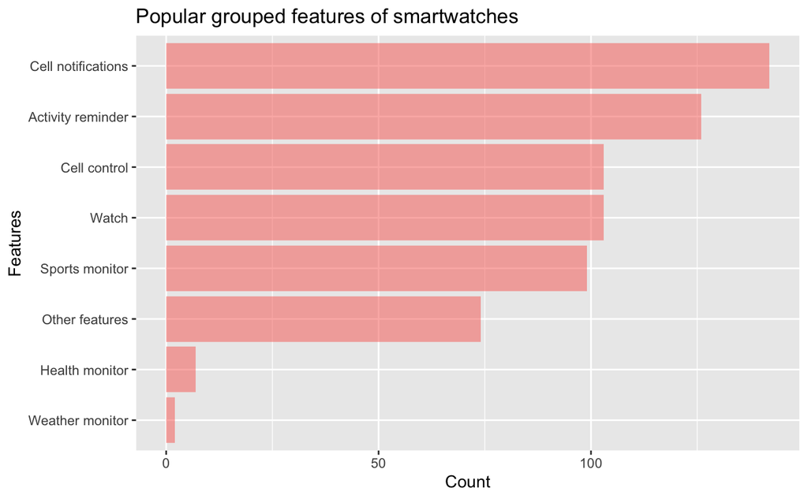

```r
# Reorder from highest frequency to lowest frequency
features_grouped_rows %>%
  ggplot(aes(x = fct_rev(fct_infreq(features_grouped)), fill = "orange", alpha=.6, width=.4)) +
  geom_bar() +
  coord_flip() +
  theme(legend.position="none")+
  labs(x = "Features", y = "Count", title = 'Popular grouped features of smartwatches')
```

### Functionalities

We want to identify which are the most used functionalities that are tracked for the users in their smartwatch.

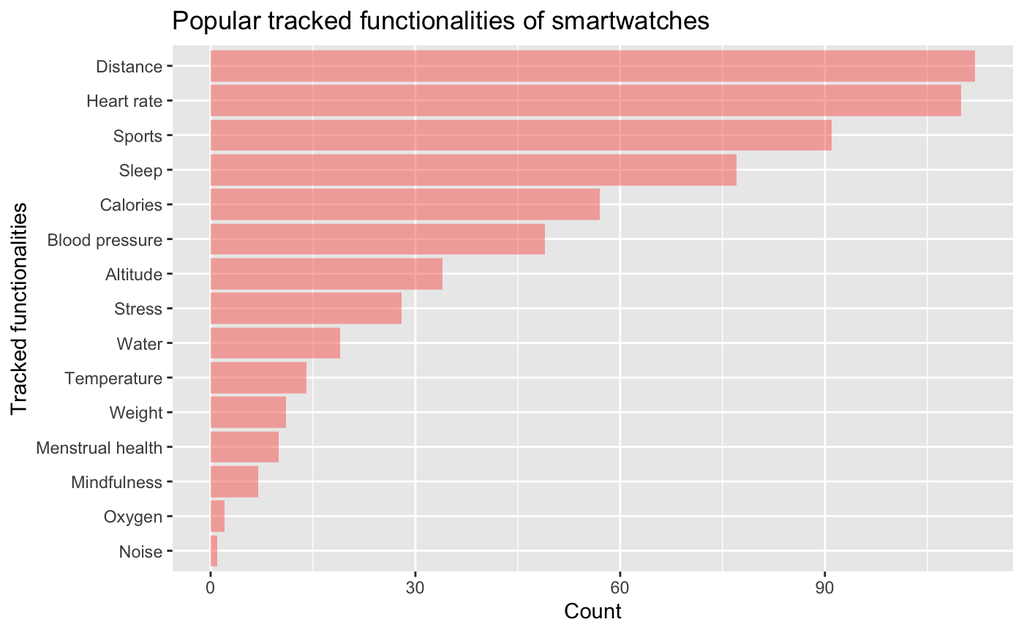

```r
# Reorder from highest frequency to lowest frequency
functionalities_grouped_rows %>% drop_na(functionalities) %>%
  ggplot(aes(x = fct_rev(fct_infreq(functionalities)), fill = "orange", alpha=.6, width=.4)) +
  geom_bar() +
  coord_flip() +
  theme(legend.position="none")+
  labs(x = "Tracked functionalities", y = "Count", title = 'Popular tracked functionalities of smartwatches')
```

### User activities

We want to know which are the sport activities most tracked for the users in their smartwatch.

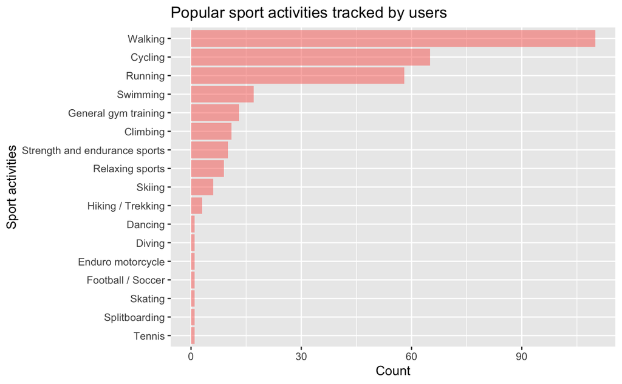

```r
# Reorder from highest frequency to lowest frequency
activities_grouped_rows %>% drop_na(activities) %>%
  ggplot(aes(x = fct_rev(fct_infreq(activities)), fill = "orange", alpha=.6, width=.4)) +
  geom_bar() +
  coord_flip() +
  theme(legend.position="none")+
  labs(x = "Sport activities", y = "Count", title = 'Popular sport activities tracked by users')
```

## Establishing relations between variables

### Usage

#### Main usage vs Gender

We want to identify if there are a relation between the usage of a smartwatch per gender

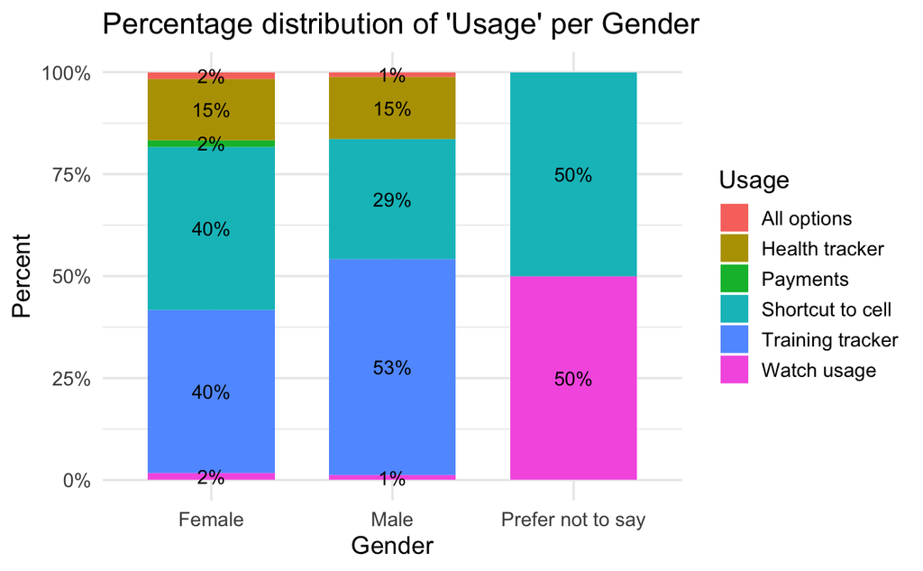

```r
gender_main_usage <- swu %>%
  group_by(gender, usage) %>%
  summarise(count = n()) %>%
  mutate(perc = count/sum(count), ratio = scales::percent(count/sum(count)))%>%
  drop_na(usage)
# Chart
ggplot(gender_main_usage, aes(x = factor(gender), y = perc*100, fill = factor(usage))) +
  geom_bar(stat="identity", width = 0.7, position="fill") +
  labs(x = "Gender", y = "Percent", fill = "usage", title = "Percentage distribution of 'Usage' per Gender") +
  theme_minimal(base_size = 14) +
  geom_text(data = gender_main_usage, aes(y = count, label = ratio), position = position_fill(vjust = 0.5)) +
  scale_y_continuous(labels = scales::percent_format(accuracy = 5L)) +
  guides(fill = guide_legend(title="Usage"))
```

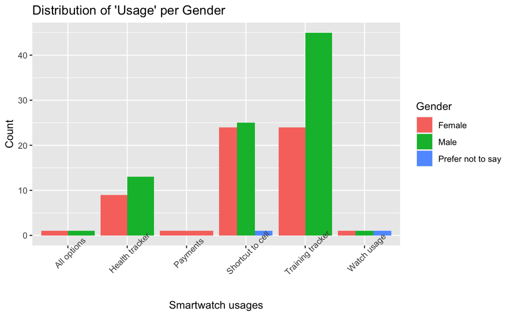

```r
# Grouped
ggplot(data = gender_main_usage, aes(fill = gender, y = count, x = usage)) +
  geom_bar(position="dodge", stat="identity") +
  labs(x = "Smartwatch usages", y = "Count", title = "Distribution of 'Usage' per Gender") +
  theme(axis.text.x = element_text(angle = 45)) +
  guides(fill=guide_legend(title="Gender"))
```

#### Main usage vs Age

We want to identify if there are a relation between the usage of a smartwatch per age

[figure not shown]

```r
age_main_usage <- swu %>%
  group_by(age, usage) %>%
  summarise(count = n()) %>%
  mutate(perc = count/sum(count), ratio = scales::percent(count/sum(count))) %>%
  drop_na(usage)
# Chart
ggplot(age_main_usage, aes(x = factor(age), y = perc*100, fill = factor(usage))) +
  geom_bar(stat="identity", width = 0.7, position="fill") +
  labs(x = "Age", y = "Percent", fill = "usage", title = "Percentage distribution of 'Main usage' per Age") +
  theme_minimal(base_size = 14) +
  geom_text(data = age_main_usage, aes(y = count, label = ratio), position = position_fill(vjust = 0.5)) +
  scale_y_continuous(labels = scales::percent_format(accuracy = 5L)) +
  guides(fill=guide_legend(title="Usage")) +
  theme(axis.text.x = element_text(angle = 45))
```

### Features

#### Features vs Gender

We want to identify if there are a relation between the used features of a smartwatch per gender

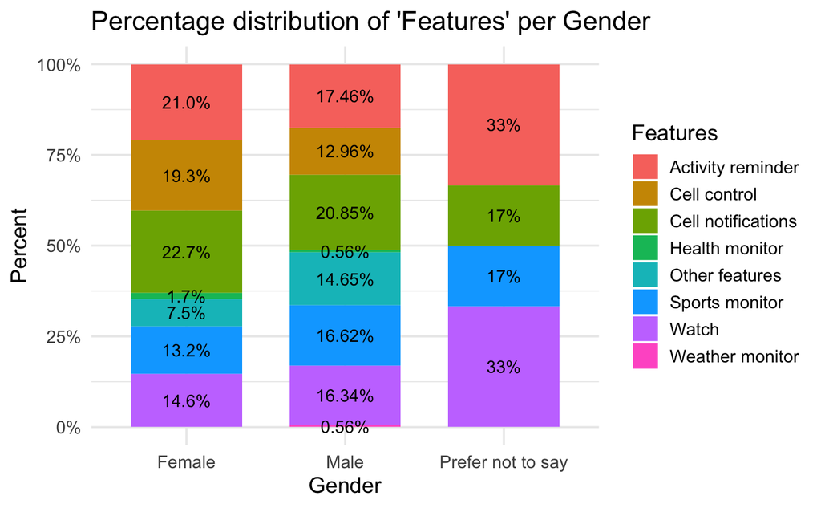

```r
gender_features <- features_grouped_rows %>%
  group_by(gender, features_grouped) %>%
  summarise(count = n()) %>%
  mutate(perc = count/sum(count), ratio = scales::percent(count/sum(count))) %>%
  drop_na(features_grouped)
# Chart
ggplot(gender_features, aes(x = factor(gender), y = perc*100, fill = factor(features_grouped))) +
  geom_bar(stat="identity", width = 0.7, position="fill") +
  labs(x = "Gender", y = "Percent", fill = "features_grouped", title = "Percentage distribution of 'Features' per Gender") +
  theme_minimal(base_size = 14) +
  geom_text(data = gender_features, aes(y = count, label = ratio), position = position_fill(vjust = 0.5)) +
  scale_y_continuous(labels = scales::percent_format(accuracy = 5L)) +
  guides(fill=guide_legend(title="Features"))
```

#### Features vs Age

We want to identify if there are a relation between the used features of a smartwatch per age.

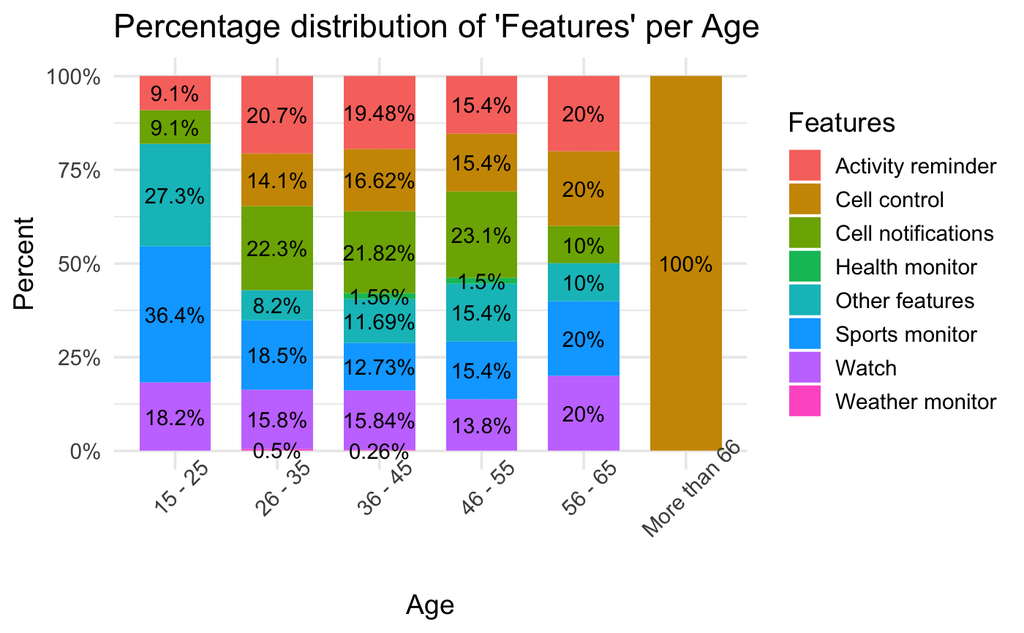

```r
age_features <- features_grouped_rows %>%
  group_by(age, features_grouped) %>%
  summarise(count = n()) %>%
  mutate(perc = count/sum(count), ratio = scales::percent(count/sum(count))) %>%
  drop_na(features_grouped)
# Chart
ggplot(age_features, aes(x = factor(age), y = perc*100, fill = factor(features_grouped))) +
  geom_bar(stat="identity", width = 0.7, position="fill") +
  labs(x = "Age", y = "Percent", fill = "features_grouped", title = "Percentage distribution of 'Features' per Age") +
  theme_minimal(base_size = 14) +
  geom_text(data = age_features, aes(y = count, label = ratio), position = position_fill(vjust = 0.5)) +
  scale_y_continuous(labels = scales::percent_format(accuracy = 5L)) +
  guides(fill=guide_legend(title="Features")) +
  theme(axis.text.x = element_text(angle = 45))
```

### Tracked functionalities

#### Functionalities vs Gender

We want to identify if there are a relation between the tracked functionalities of a smartwatch per gender.

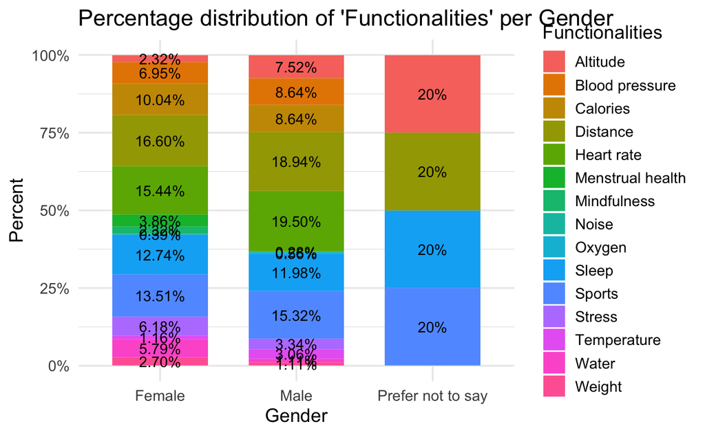

```r
gender_functionalities <- functionalities_grouped_rows %>%
  group_by(gender, functionalities) %>%
  summarise(count = n()) %>%
  mutate(perc = count/sum(count), ratio = scales::percent(count/sum(count))) %>%
  drop_na(functionalities)
# Chart
ggplot(gender_functionalities, aes(x = factor(gender), y = perc*100, fill = factor(functionalities))) +
  geom_bar(stat="identity", width = 0.7, position="fill") +
  labs(x = "Gender", y = "Percent", fill = "functionalities", title = "Percentage distribution of 'Functionalities' per Gender") +
  theme_minimal(base_size = 14) +
  geom_text(data = gender_functionalities, aes(y = count, label = ratio), position = position_fill(vjust = 0.5)) +
  scale_y_continuous(labels = scales::percent_format(accuracy = 5L)) +
  guides(fill=guide_legend(title="Functionalities"))
```

#### Functionalities vs Age

We want to identify if there are a relation between the tracked functionalities of a smartwatch per age.

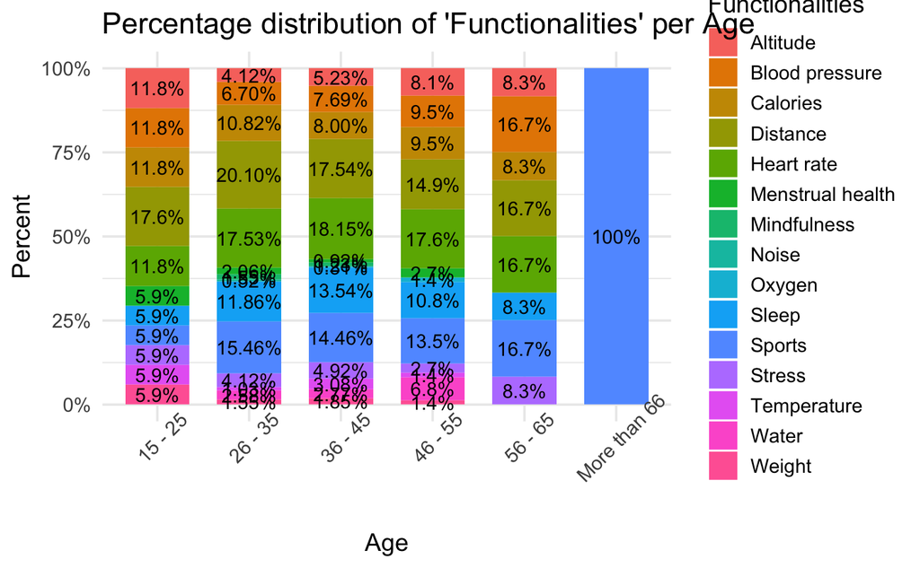

```r
age_functionalities <- functionalities_grouped_rows %>%
  group_by(age, functionalities) %>%
  summarise(count = n()) %>%
  mutate(perc = count/sum(count), ratio = scales::percent(count/sum(count))) %>%
  drop_na(functionalities)
# Chart
ggplot(age_functionalities, aes(x = factor(age), y = perc*100, fill = factor(functionalities))) +
  geom_bar(stat="identity", width = 0.7, position="fill") +
  labs(x = "Age", y = "Percent", fill = "functionalities", title = "Percentage distribution of 'Functionalities' per Age") +
  theme_minimal(base_size = 14) +
  geom_text(data = age_functionalities, aes(y = count, label = ratio), position = position_fill(vjust = 0.5)) +
  scale_y_continuous(labels = scales::percent_format(accuracy = 5L)) +
  guides(fill=guide_legend(title="Functionalities")) +
  theme(axis.text.x = element_text(angle = 45))
```

### Activities

#### Activities vs Gender

We want to identify if there are a relation between the sport activities tracked by users per gender.

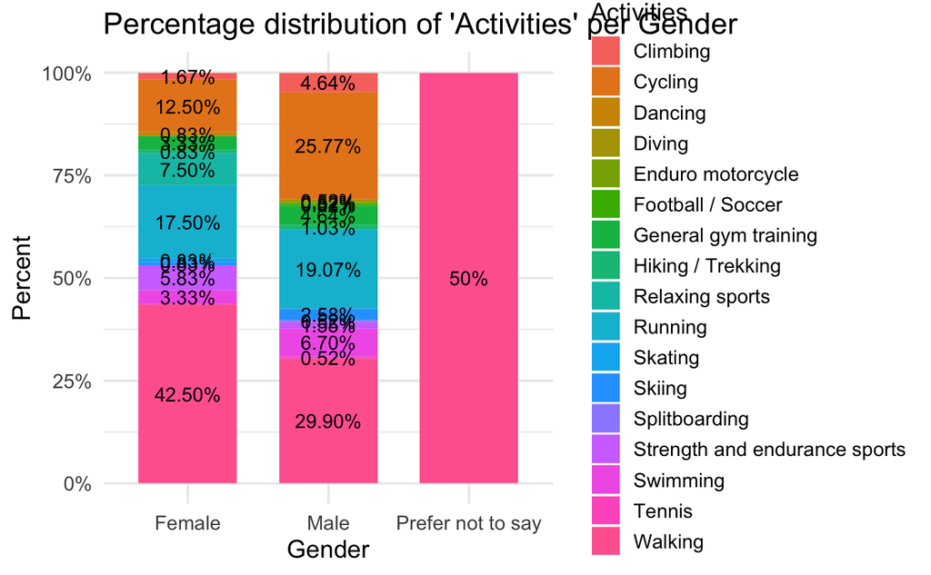

```r
gender_activities <- activities_grouped_rows %>%
  group_by(gender, activities) %>%
  summarise(count = n()) %>%
  mutate(perc = count/sum(count), ratio = scales::percent(count/sum(count))) %>%
  drop_na(activities)
# Chart
ggplot(gender_activities, aes(x = factor(gender), y = perc*100, fill = factor(activities))) +
  geom_bar(stat="identity", width = 0.7, position="fill") +
  labs(x = "Gender", y = "Percent", fill = "activities", title = "Percentage distribution of 'Activities' per Gender") +
  theme_minimal(base_size = 14) +
  geom_text(data = gender_activities, aes(y = count, label = ratio), position = position_fill(vjust = 0.5)) +
  scale_y_continuous(labels = scales::percent_format(accuracy = 5L)) +
  guides(fill=guide_legend(title="Activities"))
```

#### Activities vs Age

We want to identify if there are a relation between the sport activities tracked by users per age

```r
age_activities <- activities_grouped_rows %>%
  group_by(age, activities) %>%
  summarise(count = n()) %>%
  mutate(perc = count/sum(count), ratio = scales::percent(count/sum(count))) %>%
  drop_na(activities)

# Chart
ggplot(age_activities, aes(x = factor(age), y = perc*100, fill = factor(activities))) +
  geom_bar(stat="identity", width = 0.7, position="fill") +
  labs(x = "Age", y = "Percent", fill = "activities", title = "Percentage distribution of 'Activities' per Age") +
  theme_minimal(base_size = 14) +
  geom_text(data = age_activities, aes(y = count, label = ratio), position = position_fill(vjust = 0.5)) +
  scale_y_continuous(labels = scales::percent_format(accuracy = 5L)) +
  guides(fill=guide_legend(title="Activities")) +
  theme(axis.text.x = element_text(angle = 45))
```

[output not shown]